# Boston Metropolitan Bicycle Mobility 4.0

## Author(s)

- Author1 = {"name": "Vidur Chandra", "affiliation": "UBC Sauder School of Business", "email": "vchandra@student.ubc.ca",}
- Author2 = {"name": "Zijiao Feng", "affiliation": "UBC Sauder School of Business", "email": "susanfzj@student.ubc.ca"}
- Author3 = {"name": "Rhea Gupta", "affiliation": "UBC Sauder School of Business", "email": "rheag18@student.ubc.ca"}
- Author4 = {"name": "Carlos Alexandre Nako", "affiliation": "UBC Sauder School of Business", "email": "cnako@student.ubc.ca"}
- Author5 = {"name": "Lisa Maria Ruehrnoessl", "affiliation": "UBC Sauder School of Business", "email": "limaru@student.ubc.ca"}

## Keywords

keywords=["bikesharing", "Boston", "BlueBikes", "transportation 4.0", "mobility"]

# Purpose

The Massachusetts state department of transportation recognized that even for relatively small trips automobiles are being used throughout the state. The department has decided to encourage the use of bicycles and make cities more bicycle friendly. Keeping in mind the increasing population and lack of space in Boston the state wants to encourage people to become everyday cyclists in Boston. They also want to promote health and wellbeing and curb greenhouse gas emissions from vehicles. Boston has a bikesharing service called Bluebikes which is becoming an integral part of the city’s public transit network. **We want to help the state rethink bicycle mobility in Boston by proposing improvements such that the bikeshare network can benefit from the business distribution in the city. We would do that by analyzing the following questions.**

**Questions:**

1. Does the concentration and type of businesses in a particular ZIP code correlate with the number of Bluebikes trips in that area?
2. Does this change if we look at the different user types (subscription vs. one-off riders)?

# Methodology

In order to answer the questions above, we mainly utilize four datasets. The first dataset is Bluebikes Trip Data, which contains user trip data from June - August 2021. The next datasets are the Foursquare-Venues and Foursquare-Categories dataset, to analyze business in Boston with respect to their ZIP code, type of business and categories. Lastly, we use the zipcode dataset to map locations and zones across the Foursquare and Bluebikes datasets.

Further we have carried out the following tasks in order to answer our business questions:

- **Data Dictionary:** We identified 4 datasets and created a data dictionary in order to store information about our data such as meaning, relationships to other data, origin, usage, and format.
- **Database Setup and Data preparation:**
  1. Normalization of the database resulted in a set of 5 tables from the input dataset of 4 tables. The ZIP code and Foursquare were already in normal format. For those datasets the relevant columns for the analysis were kept and the ones not relevant were dropped. The Bluebikes dataset is at the 2nd normal form and to facilitate handling in the database, it was split into 2 tables to transform into 3rd normal form. As with the other datasets, the relevant columns for the analysis were kept and the ones not relevant were dropped **[Section 10-Appendix]**
  2. After normalization we created our tables in pgadmin, connected to our AWS database and loaded our data into the tables.
- **Exploratory Data Analysis:** We carried out exploratory data analysis on our data by establishing a connection with our AWS database, using sql queries and python libraries.
  1. We produced cross-plots in order to understand the data, with possible trends to formulate the initial modeling hypothesis. Cross plots include count of venues and count of trips, count of stations and count of trips and the count of stations and count of venues **[Section 7.2.1- Graph 1,2,3]**. For each of those charts, each data point is an aggregation of the data into a ZIP code.
  2. We produced a correlation matrix to check the correlation between number of trips number of venues and the correlation between number of trips and the number of stations**[Section 7.2.1- Table 1]**
- **Analysis:** As the final step, we analyzed the data in order to identify the number of venues in each category and checked if it correlates with a higher usage of Bluebikes service across every ZIP code. We also assesed if this changes when we look at the different user types (subscription vs. one-off riders).
  1. To understand if the concentration of any specific type of venue has a stronger correlation with the trip, the count of each type of venue was plotted against the number of trips and the correlation matrix was calculated **[Section 7.2.2-Graph 4, Table 2]**
  2. Just looking at the correlation matrix can be misleading for this analysis as venues that show stronger correlation are not necessarily wide spread throughout the city. To assess this, a coverage list was calculated to see what percentage of the zip codes that trips also had each type of venue **[Section 7.2.2-Table 3]**
  3. We use linear regression (target= number of stations, independent variables= number of trips and number of the selected venues) to verify which areas are overserved and underserved. Results were then placed in a cluster and mapped to easily visualize which ones are underserved and overserved **[Section 7.2.2- Figure 1]**
  4. Similar analysis was performed with the trip broken down between subscribers and non-subcribers **[Section 7.2.3- Figure 2, Figure 3]**
- **Summary of Findings:** Lastly, we discuss our results, provide our recommendations and identify potential limitations with our analysis **[Section 5 and Section 6]**

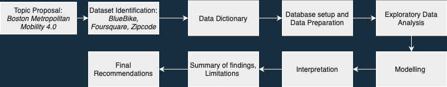

# Datasets and Data Dictionary

`Datasets and updated Data Dictionary is attached as a supplemental file`.